**Piotr Duszak - praca domowa 5 - wykorzystanie metody "permutational variable importance" na przykładzie, klasyfikacji, czy grzyb jest jadalny, czy trujący**

W niniejszym notebooku będzie wykorzystywana metoda do sprawdzania ważności zmiennych na przykładzie klasyfikacji grzybów (tego czy jest jadalny, czy trujący, na podstawie szeregu parametrów określających jego kształt, kolor, zapach, itp.)

Zostały naczuone 4 modele (3 x losowy las) oraz sieć neuronowa.

# Część własciwa

## 2. Obliczenie "permutacyjnego znaczenia zmiennej" dla modelu drzewiastego

Poniżej wykres prezentujący ważność zmiennych dla modelu drzewiastego typu las losowy (o maksymalnej głębokości 5)

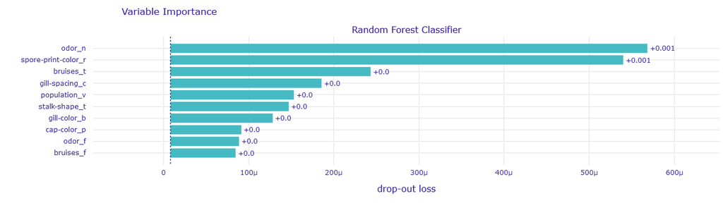

Wygląda na to, że dla tego modelu najważniejszy jest paramatr odor_n, który oznacza, że grzyb nie posiadał zapachu. Postanowiono sprawdzić zależność między zapachem a tym, czy grzyb jest jadalny, czy trujący. Poniżej histogram prezentujący tę zależność.

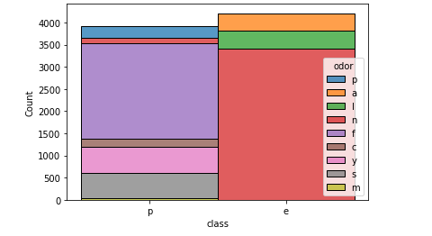

Jak widać jest bardzo duża zależność pomiędzy tym, czy grzyb pachnie oraz tym czy jest jadalny czy trujący (to znaczy jeśli grzyb nie pachnie lub ma zapach l=anyżku lub a=migdałów, to jest on prawie na pewno jadalny, a w przeciwnym wypadku jest prawie na pewno trujący).

**Komentarz:**

Dla tego modelu najważniejszą cechą był parametr odor_n oznaczający, że grzyb nie ma zapachu. Sprawdzono rozkład zapachów wśród, grzybów jadalnych i trujących i okazało się, że rzeczywiście jest bardzo duża korelacja pomiędzy zapachem, a jadalnością grzyba.

## 3. Nauczenie innych modeli oraz sprawdzenie ważności zmiennych

Postanowiono przetestować trzy kolejne modele:

- Również model typu las losowy, ale tym razem na wejście nie podano informacji o zapachu
- Las losowy o głębokości co najwyżej 3
- Sieć neuronowa

Poniżej zagregowane wykresy prezentujące ważność zmiennych dla tych czterech modeli.

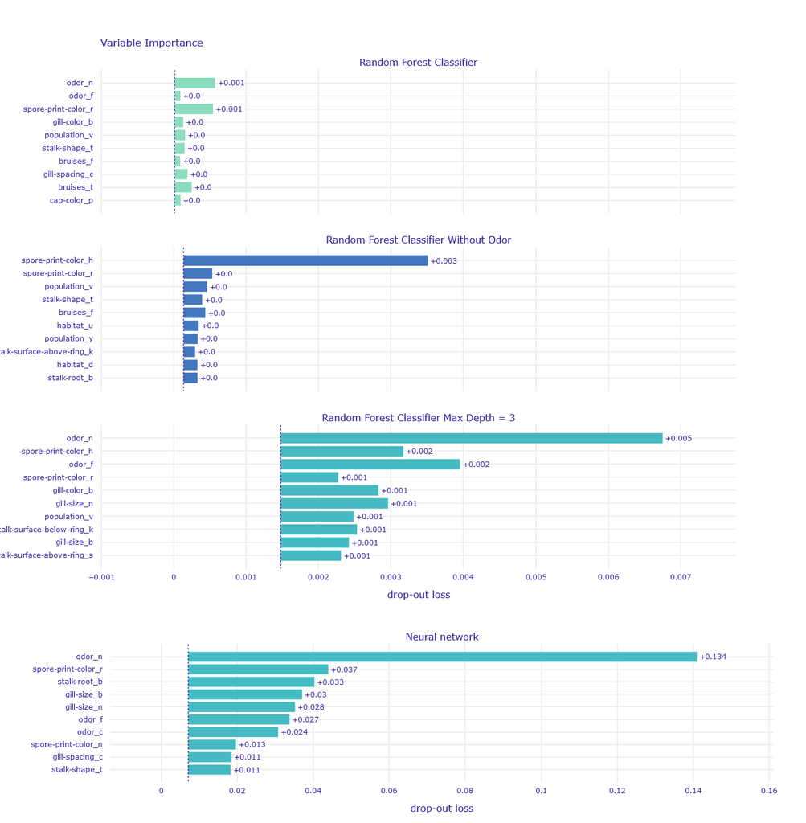

**Komentarz:**

- Dla wszystkich modeli, które zostały wytrenowane najważniejszym parametrem był odor_n (o ile był on dla modelu dostęnpy)
- Mimo, że dla pierwotnego modelu drugim najważniejszym parametrem było spore-print-color_r, to dla modelu, który nie miał dostępu do indormacji o zapachu grzyba to nie był najważniejszy parametr (był nim spore-print-color_h, czyli parametr też mówiący o kolorze zarodników, ale o innym kolorze)
- Model pozbawiony informacji o zapachu był lepszy (miał wyższą trafność, oraz niższy drop-out loss) niż model, który posiadał informacje o zapachu, ale miał mniejszą głebokość
- Pierwsze dwa najważniejsze parametry modelu sieciowego są takie same jak pierwotnego modelu drzewiastego, ale później się już różnią
- Wartości drop-out lossa są wielokrotnie większe dla sieci neuronowej w stosunku do modeli drzewiastych (dlatego wykres dla sieci został przedstawiony osobno z inną skalą)

# Załącznik

## Wczytanie i przygotowanie danych

```python
import pandas as pd
import numpy as np
# Wczytanie danych i wyświetlenie kilku pierwszych i ostatnich wierszy
shrooms_data = pd.read_csv('drive/MyDrive/mushrooms.csv')
shrooms_data
```

|  | class | cap-shape | cap-surface | cap-color | bruises | odor | gill-attachment | gill-spacing | gill-size | gill-color | stalk-shape | stalk-root | stalk-surface-above-ring | stalk-surface-below-ring | stalk-color-above-ring | stalk-color-below-ring | veil-type | veil-color | ring-number | ring-type | spore-print-color | population | habitat |
| --- | --- | --- | --- | --- | --- | --- | --- | --- | --- | --- | --- | --- | --- | --- | --- | --- | --- | --- | --- | --- | --- | --- | --- |
| 0 | p | x | s | n | t | p | f | c | n | k | e | e | s | s | w | w | p | w | o | p | k | s | u |
| 1 | e | x | s | y | t | a | f | c | b | k | e | c | s | s | w | w | p | w | o | p | n | n | g |
| 2 | e | b | s | w | t | l | f | c | b | n | e | c | s | s | w | w | p | w | o | p | n | n | m |
| 3 | p | x | y | w | t | p | f | c | n | n | e | e | s | s | w | w | p | w | o | p | k | s | u |
| 4 | e | x | s | g | f | n | f | w | b | k | t | e | s | s | w | w | p | w | o | e | n | a | g |
| ... | ... | ... | ... | ... | ... | ... | ... | ... | ... | ... | ... | ... | ... | ... | ... | ... | ... | ... | ... | ... | ... | ... | ... |
| 8119 | e | k | s | n | f | n | a | c | b | y | e | ? | s | s | o | o | p | o | o | p | b | c | l |
| 8120 | e | x | s | n | f | n | a | c | b | y | e | ? | s | s | o | o | p | n | o | p | b | v | l |
| 8121 | e | f | s | n | f | n | a | c | b | n | e | ? | s | s | o | o | p | o | o | p | b | c | l |
| 8122 | p | k | y | n | f | y | f | c | n | b | t | ? | s | k | w | w | p | w | o | e | w | v | l |
| 8123 | e | x | s | n | f | n | a | c | b | y | e | ? | s | s | o | o | p | o | o | p | o | c | l |

8124 rows × 23 columns

Jak widać powyżej dane mają 8124 wierszy. Każdy rekord (wiersz) składa się z informacji, czy grzyb jest jadalny, ale również serii parametrów. Wszystkie parametry są kategoryczne (nie ma żadnych danych liczbowych).

```python
# Wyświetlenie liczności każdej kategorii, itp.
shrooms_data.describe()
```

|  | class | cap-shape | cap-surface | cap-color | bruises | odor | gill-attachment | gill-spacing | gill-size | gill-color | stalk-shape | stalk-root | stalk-surface-above-ring | stalk-surface-below-ring | stalk-color-above-ring | stalk-color-below-ring | veil-type | veil-color | ring-number | ring-type | spore-print-color | population | habitat |
| --- | --- | --- | --- | --- | --- | --- | --- | --- | --- | --- | --- | --- | --- | --- | --- | --- | --- | --- | --- | --- | --- | --- | --- |
| count | 8124 | 8124 | 8124 | 8124 | 8124 | 8124 | 8124 | 8124 | 8124 | 8124 | 8124 | 8124 | 8124 | 8124 | 8124 | 8124 | 8124 | 8124 | 8124 | 8124 | 8124 | 8124 | 8124 |
| unique | 2 | 6 | 4 | 10 | 2 | 9 | 2 | 2 | 2 | 12 | 2 | 5 | 4 | 4 | 9 | 9 | 1 | 4 | 3 | 5 | 9 | 6 | 7 |
| top | e | x | y | n | f | n | f | c | b | b | t | b | s | s | w | w | p | w | o | p | w | v | d |
| freq | 4208 | 3656 | 3244 | 2284 | 4748 | 3528 | 7914 | 6812 | 5612 | 1728 | 4608 | 3776 | 5176 | 4936 | 4464 | 4384 | 8124 | 7924 | 7488 | 3968 | 2388 | 4040 | 3148 |

Parametry mają różną liczbę kategorii, do której mogą należeć. Przykładowo jest 6 rodzajów kształtów kapelusza, ale aż 10 rodzajów koloru. Aczkolwiek w takiej formie te parametry są nieprzydatne jako wejście do sieci neuronowej. Żeby były przydatne trzeba przerobić je na kodowanie liczbowe albo jeszcze lepiej one-hot-encoding.

```python
# Zamiana kodowania na one-hot-encoding
shrooms_data_ohe = shrooms_data.copy()
for column in shrooms_data_ohe.columns[1:]:
  for vals in shrooms_data_ohe[column].unique():
    shrooms_data_ohe.loc[shrooms_data_ohe[column]==vals , '_'.join([column, vals])] = 1
    shrooms_data_ohe.loc[shrooms_data_ohe[column]!=vals , '_'.join([column, vals])] = 0
  shrooms_data_ohe.drop(column, axis=1, inplace=True)
shrooms_data_ohe.loc[shrooms_data_ohe['class']=='e', 'class'] = 1
shrooms_data_ohe.loc[shrooms_data_ohe['class']=='p', 'class'] = 0
shrooms_data_ohe
```

|  | class | cap-shape_x | cap-shape_b | cap-shape_s | cap-shape_f | cap-shape_k | cap-shape_c | cap-surface_s | cap-surface_y | cap-surface_f | cap-surface_g | cap-color_n | cap-color_y | cap-color_w | cap-color_g | cap-color_e | cap-color_p | cap-color_b | cap-color_u | cap-color_c | cap-color_r | bruises_t | bruises_f | odor_p | odor_a | odor_l | odor_n | odor_f | odor_c | … |
| --- | --- | --- | --- | --- | --- | --- | --- | --- | --- | --- | --- | --- | --- | --- | --- | --- | --- | --- | --- | --- | --- | --- | --- | --- | --- | --- | --- | --- | --- | --- |
| 0 | 0 | 1.0 | 0.0 | 0.0 | 0.0 | 0.0 | 0.0 | 1.0 | 0.0 | 0.0 | 0.0 | 1.0 | 0.0 | 0.0 | 0.0 | 0.0 | 0.0 | 0.0 | 0.0 | 0.0 | 0.0 | 1.0 | 0.0 | 1.0 | 0.0 | 0.0 | 0.0 | 0.0 | 0.0 | … |
| 1 | 1 | 1.0 | 0.0 | 0.0 | 0.0 | 0.0 | 0.0 | 1.0 | 0.0 | 0.0 | 0.0 | 0.0 | 1.0 | 0.0 | 0.0 | 0.0 | 0.0 | 0.0 | 0.0 | 0.0 | 0.0 | 1.0 | 0.0 | 0.0 | 1.0 | 0.0 | 0.0 | 0.0 | 0.0 | … |
| 2 | 1 | 0.0 | 1.0 | 0.0 | 0.0 | 0.0 | 0.0 | 1.0 | 0.0 | 0.0 | 0.0 | 0.0 | 0.0 | 1.0 | 0.0 | 0.0 | 0.0 | 0.0 | 0.0 | 0.0 | 0.0 | 1.0 | 0.0 | 0.0 | 0.0 | 1.0 | 0.0 | 0.0 | 0.0 | … |
| 3 | 0 | 1.0 | 0.0 | 0.0 | 0.0 | 0.0 | 0.0 | 0.0 | 1.0 | 0.0 | 0.0 | 0.0 | 0.0 | 1.0 | 0.0 | 0.0 | 0.0 | 0.0 | 0.0 | 0.0 | 0.0 | 1.0 | 0.0 | 1.0 | 0.0 | 0.0 | 0.0 | 0.0 | 0.0 | … |
| 4 | 1 | 1.0 | 0.0 | 0.0 | 0.0 | 0.0 | 0.0 | 1.0 | 0.0 | 0.0 | 0.0 | 0.0 | 0.0 | 0.0 | 1.0 | 0.0 | 0.0 | 0.0 | 0.0 | 0.0 | 0.0 | 0.0 | 1.0 | 0.0 | 0.0 | 0.0 | 1.0 | 0.0 | 0.0 | … |
| ... | ... | ... | ... | ... | ... | ... | ... | ... | ... | ... | ... | ... | ... | ... | ... | ... | ... | ... | ... | ... | ... | ... | ... | ... | ... | ... | ... | ... | ... | … |
| 8119 | 1 | 0.0 | 0.0 | 0.0 | 0.0 | 1.0 | 0.0 | 1.0 | 0.0 | 0.0 | 0.0 | 1.0 | 0.0 | 0.0 | 0.0 | 0.0 | 0.0 | 0.0 | 0.0 | 0.0 | 0.0 | 0.0 | 1.0 | 0.0 | 0.0 | 0.0 | 1.0 | 0.0 | 0.0 | … |
| 8120 | 1 | 1.0 | 0.0 | 0.0 | 0.0 | 0.0 | 0.0 | 1.0 | 0.0 | 0.0 | 0.0 | 1.0 | 0.0 | 0.0 | 0.0 | 0.0 | 0.0 | 0.0 | 0.0 | 0.0 | 0.0 | 0.0 | 1.0 | 0.0 | 0.0 | 0.0 | 1.0 | 0.0 | 0.0 | … |
| 8121 | 1 | 0.0 | 0.0 | 0.0 | 1.0 | 0.0 | 0.0 | 1.0 | 0.0 | 0.0 | 0.0 | 1.0 | 0.0 | 0.0 | 0.0 | 0.0 | 0.0 | 0.0 | 0.0 | 0.0 | 0.0 | 0.0 | 1.0 | 0.0 | 0.0 | 0.0 | 1.0 | 0.0 | 0.0 | … |
| 8122 | 0 | 0.0 | 0.0 | 0.0 | 0.0 | 1.0 | 0.0 | 0.0 | 1.0 | 0.0 | 0.0 | 1.0 | 0.0 | 0.0 | 0.0 | 0.0 | 0.0 | 0.0 | 0.0 | 0.0 | 0.0 | 0.0 | 1.0 | 0.0 | 0.0 | 0.0 | 0.0 | 0.0 | 0.0 | … |
| 8123 | 1 | 1.0 | 0.0 | 0.0 | 0.0 | 0.0 | 0.0 | 1.0 | 0.0 | 0.0 | 0.0 | 1.0 | 0.0 | 0.0 | 0.0 | 0.0 | 0.0 | 0.0 | 0.0 | 0.0 | 0.0 | 0.0 | 1.0 | 0.0 | 0.0 | 0.0 | 1.0 | 0.0 | 0.0 | … |

8124 rows × 118 columns

Po przetworzeniu danych na one-hot-encoding dla każdego grzyba mamy 117 parametrów wejściowych oraz 1 wyjściowy oznaczający, czy grzyb jest jadalny, czy trujący.

```python
# Przekonwertowanie do numpy array, pomieszanie wierszy i rozdzielenie na zbriór uczący, testowy i walidacyjny
data = shrooms_data_ohe.sample(frac=1, random_state=0)
train, val, test = data[:4062], data[4062:6093], data[6093:]
train_y, train_x = train['class'].astype(int), train.loc[:, 'cap-shape_x':'habitat_l']
val_y, val_x = val['class'].astype(int), val.loc[:, 'cap-shape_x':'habitat_l']
test_y, test_x = test['class'].astype(int), test.loc[:, 'cap-shape_x':'habitat_l']
```

Dane zostały podzielone na dane treningowe, walidacyjne oraz testowe (każdy zestaw na wejście oraz wyjście).

## 1. Nauczenie modelu drzewiastego (RFC)

Został nauczony model drzewiasty typu las losowy, o maksymalnej głębokości 5.

```python
from sklearn.ensemble import RandomForestClassifier

np.random.seed(0)
# Stworzenie i wytrenowanie modelu
tree_classifier = RandomForestClassifier(max_depth=5)
tree_classifier.fit(train_x, train_y)
```

```
RandomForestClassifier(bootstrap=True, ccp_alpha=0.0, class_weight=None,
                       criterion='gini', max_depth=5, max_features='auto',
                       max_leaf_nodes=None, max_samples=None,
                       min_impurity_decrease=0.0, min_impurity_split=None,
                       min_samples_leaf=1, min_samples_split=2,
                       min_weight_fraction_leaf=0.0, n_estimators=100,
                       n_jobs=None, oob_score=False, random_state=None,
                       verbose=0, warm_start=False)
```

```python
tc_score_train = tree_classifier.score(train_x, train_y)
tc_score_val = tree_classifier.score(val_x, val_y)
tc_score_test = tree_classifier.score(test_x, test_y)
print('Accuracy on train set: {}'.format(tc_score_train))
print('Accuracy on val set: {}'.format(tc_score_val))
print('Accuracy on test set: {}'.format(tc_score_test))
```

```
Accuracy on train set: 0.9903988183161004
Accuracy on val set: 0.9916297390448056
Accuracy on test set: 0.9906450024618415
```

Został on nauczony na zbiorze treningowym i osiągnął na nim trafność prawie 100%. Podobną trafność osiągnął na zbiorze walidacyjnym i testowym.

## 2. Obliczenie "permutacyjnego znaczenia zmiennej" dla modelu drzewiastego

```python
# !pip install dalex
```

```python
import dalex as dx

model_rfc_explainer = dx.Explainer(tree_classifier, train_x, train_y, label='Random Forest Classifier')
mp_rfc = model_rfc_explainer.model_parts()
mp_rfc.plot()
```

```
Preparation of a new explainer is initiated

  -> data              : 4062 rows 117 cols
  -> target variable   : Parameter 'y' was a pandas.Series. Converted to a numpy.ndarray.
  -> target variable   : 4062 values
  -> model_class       : sklearn.ensemble._forest.RandomForestClassifier (default)
  -> label             : Random Forest Classifier
  -> predict function  : <function yhat_proba_default at 0x7fe8bb97d830> will be used (default)
  -> predict function  : Accepts pandas.DataFrame and numpy.ndarray.
  -> predicted values  : min = 0.00446, mean = 0.52, max = 0.986
  -> model type        : classification will be used (default)
  -> residual function : difference between y and yhat (default)
  -> residuals         : min = -0.671, mean = -7.46e-05, max = 0.349
  -> model_info        : package sklearn

A new explainer has been created!
```

[interactive chart not shown]

Wygląda na to, że dla tego modelu najważniejszy jest paramatr odor_n, który oznacza, że grzyb nie posiadał zapachu. Postanowiono sprawdzić zależność między zapachem a tym, czy grzyb jest jadalny, czy trujący. Poniżej histogram prezentujący tę zależność.

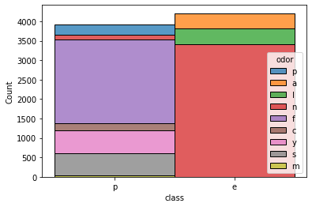

```python
import seaborn as sns

sns.histplot(x='class', data=shrooms_data, hue='odor', multiple="stack")
```

Jak widać jest bardzo duża zależność pomiędzy tym, czy grzyb pachnie oraz tym czy jest jadalny czy trujący (to znaczy jeśli grzyb nie pachnie lub ma zapach l=anyżku lub a=migdałów, to jest on prawie na pewno jadalny, a w przeciwnym wypadku jest prawie na pewno trujący).

**Komentarz:**

Dla tego modelu najważniejszą cechą był parametr odor_n oznaczający, że grzyb nie ma zapachu. Sprawdzono rozkład zapachów wśród, grzybów jadalnych i trujących i okazało się, że rzeczywiście jest bardzo duża korelacja pomiędzy zapachem, a jadalnością grzyba.

## 3. Nauczenie innych modeli oraz sprawdzenie ważności zmiennych

Postanowiono przetestować trzy kolejne modele:

- Również model typu las losowy, ale tym razem na wejście nie podano informacji o zapachu
- Las losowy o głębokości co najwyżej 3
- Sieć neuronowa

```python
cols_wo = [col for col in train_x.columns if 'odor' not in col]

np.random.seed(0)
# Stworzenie i wytrenowanie modelu
tree_classifier_wo = RandomForestClassifier(max_depth=5)
tree_classifier_wo.fit(train_x[cols_wo], train_y)
tc_score_train_wo = tree_classifier_wo.score(train_x[cols_wo], train_y)
tc_score_val_wo = tree_classifier_wo.score(val_x[cols_wo], val_y)
tc_score_test_wo = tree_classifier_wo.score(test_x[cols_wo], test_y)
print('Accuracy on train set: {}'.format(tc_score_train_wo))
print('Accuracy on val set: {}'.format(tc_score_val_wo))
print('Accuracy on test set: {}'.format(tc_score_test_wo))

model_rfc_explainer_wo = dx.Explainer(tree_classifier_wo, train_x[cols_wo], train_y, label='Random Forest Classifier Without Odor')
mp_rfc_wo = model_rfc_explainer_wo.model_parts()
mp_rfc_wo.plot()
```

```
Accuracy on train set: 0.9899064500246184
Accuracy on val set: 0.9911373707533235
Accuracy on test set: 0.9906450024618415
Preparation of a new explainer is initiated

  -> data              : 4062 rows 108 cols
  -> target variable   : Parameter 'y' was a pandas.Series. Converted to a numpy.ndarray.
  -> target variable   : 4062 values
  -> model_class       : sklearn.ensemble._forest.RandomForestClassifier (default)
  -> label             : Random Forest Classifier Without Odor
  -> predict function  : <function yhat_proba_default at 0x7fe8bb97d830> will be used (default)
  -> predict function  : Accepts pandas.DataFrame and numpy.ndarray.
  -> predicted values  : min = 0.00429, mean = 0.519, max = 0.982
  -> model type        : classification will be used (default)
  -> residual function : difference between y and yhat (default)
  -> residuals         : min = -0.676, mean = 7.08e-05, max = 0.463
  -> model_info        : package sklearn

A new explainer has been created!
```

[interactive chart not shown]

Tym razem najważniejszy był parametr spore-print-color_h oznaczający, że kolor zarodników był "czekoladowy".

```python
np.random.seed(0)
# Stworzenie i wytrenowanie modelu
tree_classifier_max_3 = RandomForestClassifier(max_depth=3)
tree_classifier_max_3.fit(train_x, train_y)
tc_score_train_max_3 = tree_classifier_max_3.score(train_x, train_y)
tc_score_val_max_3 = tree_classifier_max_3.score(val_x, val_y)
tc_score_test_max_3 = tree_classifier_max_3.score(test_x, test_y)
print('Accuracy on train set: {}'.format(tc_score_train_max_3))
print('Accuracy on val set: {}'.format(tc_score_val_max_3))
print('Accuracy on test set: {}'.format(tc_score_test_max_3))

model_rfc_explainer_max_3 = dx.Explainer(tree_classifier_max_3, train_x, train_y, label='Random Forest Classifier Max Depth = 3')
mp_rfc_max_3 = model_rfc_explainer_max_3.model_parts()
mp_rfc_max_3.plot()
```

```
Accuracy on train set: 0.9763663220088626
Accuracy on val set: 0.9753815854258986
Accuracy on test set: 0.9783357951747907
Preparation of a new explainer is initiated

  -> data              : 4062 rows 117 cols
  -> target variable   : Parameter 'y' was a pandas.Series. Converted to a numpy.ndarray.
  -> target variable   : 4062 values
  -> model_class       : sklearn.ensemble._forest.RandomForestClassifier (default)
  -> label             : Random Forest Classifier Max Depth = 3
  -> predict function  : <function yhat_proba_default at 0x7fe8bb97d830> will be used (default)
  -> predict function  : Accepts pandas.DataFrame and numpy.ndarray.
  -> predicted values  : min = 0.038, mean = 0.52, max = 0.917
  -> model type        : classification will be used (default)
  -> residual function : difference between y and yhat (default)
  -> residuals         : min = -0.76, mean = -0.000123, max = 0.492
  -> model_info        : package sklearn

A new explainer has been created!
```

[interactive chart not shown]

Znowu najważniejszy był parametr odor_n, ale na drugim miejscu jest tym razem odor_f.

```python
# Skontruowanie modelu sieci neuronowej
from tensorflow.keras import Sequential
from tensorflow.keras.layers import *
from tensorflow.keras.optimizers import *

nn_classifier = Sequential()
nn_classifier.add(Dense(64, activation='relu', input_shape=(117,)))
nn_classifier.add(Dropout(0.5))
nn_classifier.add(Dense(128, activation='relu'))
nn_classifier.add(Dropout(0.5))
nn_classifier.add(Dense(64, activation='relu'))
nn_classifier.add(Dropout(0.5))
nn_classifier.add(Dense(1, activation='sigmoid'))

# Uczenie sieci
nn_classifier.compile(optimizer=SGD(0.01), loss='binary_crossentropy', metrics='acc')
nn_classifier.fit(train_x, train_y, batch_size=8, epochs=10, validation_data=(val_x, val_y))
```

```
<tensorflow.python.keras.callbacks.History at 0x7fe838085e10>
```

```python
# Sprawdzenie skuteczności na zbiorze treningowym
nn_classifier.evaluate(train_x, train_y)
```

```
[0.003381148912012577, 0.9990152716636658]
```

```python
# Sprawdzenie skuteczności na zbiorze walidacyjnym
nn_classifier.evaluate(val_x, val_y)
```

```
[0.004278526641428471, 0.9990152716636658]
```

```python
# Sprawdzenie skuteczności na zbiorze testowym
nn_classifier.evaluate(test_x, test_y)
```

```
[0.0035599602852016687, 0.9990152716636658]
```

Można więc uznać, że to bardzo dobry klasyfikator.

```python
model_nn_explainer = dx.Explainer(nn_classifier, train_x, train_y, label='Neural network')
mp_nn = model_nn_explainer.model_parts()
mp_nn.plot()
```

```
Preparation of a new explainer is initiated

  -> data              : 4062 rows 117 cols
  -> target variable   : Parameter 'y' was a pandas.Series. Converted to a numpy.ndarray.
  -> target variable   : 4062 values
  -> model_class       : tensorflow.python.keras.engine.sequential.Sequential (default)
  -> label             : Neural network
  -> predict function  : <function yhat_tf_regression at 0x7fe8bb982290> will be used (default)
  -> predict function  : Accepts pandas.DataFrame and numpy.ndarray.
  -> predicted values  : min = 1.18e-09, mean = 0.521, max = 1.0
  -> model type        : regression will be used (default)
  -> residual function : difference between y and yhat (default)
  -> residuals         : min = -0.925, mean = -0.00136, max = 0.0482
  -> model_info        : package tensorflow

A new explainer has been created!
```

[interactive chart not shown]

I znowy najważniejszym parametrem jest odor_n. Dla łatwiejszgo porównywania wyników narysowano wszystkie wykresy na raz.

```python
mp_rfc.plot([mp_rfc_wo, mp_rfc_max_3])
mp_nn.plot()
```

[interactive chart not shown]

**Komentarz:**

- Dla wszystkich modeli, które zostały wytrenowane najważniejszym parametrem był odor_n (o ile był on dla modelu dostęnpy)
- Mimo, że dla pierwotnego modelu drugim najważniejszym parametrem było spore-print-color_r, to dla modelu, który nie miał dostępu do indormacji o zapachu grzyba to nie był najważniejszy parametr (był nim spore-print-color_h, czyli parametr też mówiący o kolorze zarodników, ale o innym kolorze)
- Model pozbawiony informacji o zapachu był lepszy (miał wyższą trafność, oraz niższy drop-out loss) niż model, który posiadał informacje o zapachu, ale miał mniejszą głebokość
- Pierwsze dwa najważniejsze parametry modelu sieciowego są takie same jak pierwotnego modelu drzewiastego, ale później się już różnią
- Wartości drop-out lossa są wielokrotnie większe dla sieci neuronowej w stosunku do modeli drzewiastych (dlatego wykres dla sieci został przedstawiony osobno z inną skalą)